# Project 1 -Forecasting

Rachel Greenlee

3/18/2022

**Midterm project for DATA624 course in CUNY’s MSDS program**

# Part A - ATM Forecast

#### In part A, I want you to forecast how much cash is taken out of 4 different ATM machines for May 2010. The data is given in a single file. The variable ‘Cash’ is provided in hundreds of dollars, other than that it is straight forward. I am being somewhat ambiguous on purpose to make this have a little more business feeling. Explain and demonstrate your process, techniques used and not used, and your actual forecast. I am giving you data via an excel file, please provide your written report on your findings, visuals, discussion and your R code via an RPubs link along with the actual.rmd file Also please submit the forecast which you will put in an Excel readable file.

## #1 Data preparation

First I load in the provided data.

```r
atm_raw <- read_csv("atm_raw.csv")
```

A first glance at the data I see there is some work to do. First, we’ll want to switch this to a wide dataset with each ATM it’s own column. Without this adjustment, we will have repeat `DATE` values which will be problematic in the tsibble format. I also see 14 cases having no value for `ATM`, these can be removed as I see these are associated with May dates (which we’ll be predicting later) and not `Cash` value is present.

```r
#inspect data
skim(atm_raw)
```

Data summary

| Name | atm_raw |
| --- | --- |
| Number of rows | 1474 |
| Number of columns | 3 |
| _______________________ |  |
| Column type frequency: |  |
| character | 2 |
| numeric | 1 |
| ________________________ |  |
| Group variables | None |

**Variable type: character**

| skim_variable | n_missing | complete_rate | min | max | empty | n_unique | whitespace |
| --- | --- | --- | --- | --- | --- | --- | --- |
| DATE | 0 | 1.00 | 20 | 22 | 0 | 379 | 0 |
| ATM | 14 | 0.99 | 4 | 4 | 0 | 4 | 0 |

**Variable type: numeric**

| skim_variable | n_missing | complete_rate | mean | sd | p0 | p25 | p50 | p75 | p100 | hist |
| --- | --- | --- | --- | --- | --- | --- | --- | --- | --- | --- |
| Cash | 19 | 0.99 | 155.57 | 376.46 | 0 | 0.5 | 73 | 114 | 10920 | ▇▁▁▁▁ |

```r
#remove cases with ATM=NA and make a wide dataset, each ATM it's own variable
atm <- atm_raw %>%
  drop_na(ATM) %>%
  spread(ATM, Cash)
```

Now that the data is reshaped, I recheck the distribution with another skim. It appears we are missing 3 values from ATM1 and 2 values from ATM2 - these will need to be imputed. Also, we note that date is set as a character, we’ll want to convert that to a date type variable, and convert the whole dataframe to a tsibble. Finally, ATM3 looks like trouble, with a distribution that suggests very few transactions in a day.

```r
skim(atm)
```

Data summary

| Name | atm |
| --- | --- |
| Number of rows | 365 |
| Number of columns | 5 |
| _______________________ |  |
| Column type frequency: |  |
| character | 1 |
| numeric | 4 |
| ________________________ |  |
| Group variables | None |

**Variable type: character**

| skim_variable | n_missing | complete_rate | min | max | empty | n_unique | whitespace |
| --- | --- | --- | --- | --- | --- | --- | --- |
| DATE | 0 | 1 | 20 | 22 | 0 | 365 | 0 |

**Variable type: numeric**

| skim_variable | n_missing | complete_rate | mean | sd | p0 | p25 | p50 | p75 | p100 | hist |
| --- | --- | --- | --- | --- | --- | --- | --- | --- | --- | --- |
| ATM1 | 3 | 0.99 | 83.89 | 36.66 | 1 | 73.0 | 91 | 108 | 180 | ▂▁▇▃▁ |
| ATM2 | 2 | 0.99 | 62.58 | 38.90 | 0 | 25.5 | 67 | 93 | 147 | ▇▅▇▇▂ |
| ATM3 | 0 | 1.00 | 0.72 | 7.94 | 0 | 0.0 | 0 | 0 | 96 | ▇▁▁▁▁ |
| ATM4 | 0 | 1.00 | 474.01 | 650.95 | 2 | 124.0 | 404 | 705 | 10920 | ▇▁▁▁▁ |

```r
#shave off unecessary hour/minute/second of date variable
atm$DATE <- str_sub(atm$DATE, end=-13)

#conver to date class
atm$DATE <- mdy(atm$DATE)
```

### Imputation

Next I’ll see how the `imputeTS` package would impute the handful of NA values using the linear (default) imputation method.

#### ATM1

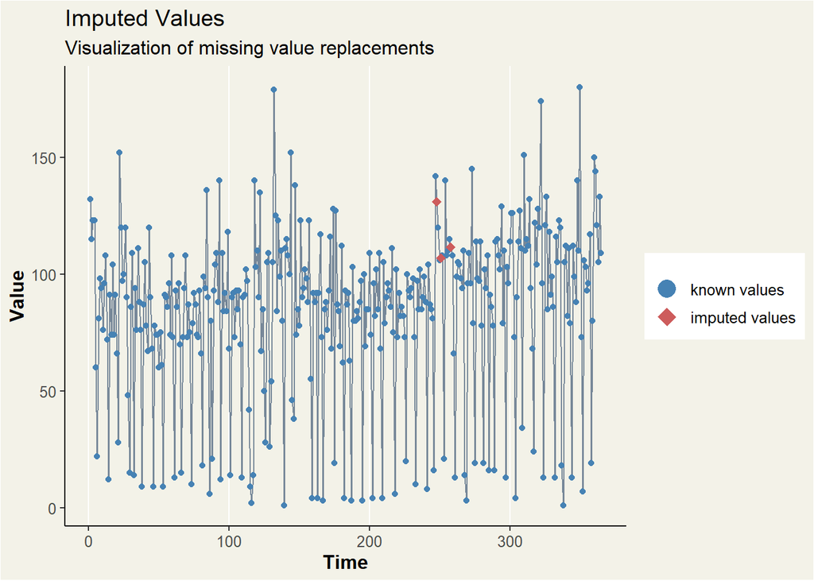

```r
#store imputation
imputation <- na_interpolation(atm$ATM1)
#plot imputation
ggplot_na_imputations(atm$ATM1, imputation) +
  my_plot_theme
```

```r
#incorporation imputation
atm$ATM1 <- imputation
```

#### ATM2

And again for ATM2 we see reasonable values for the default imputation method.

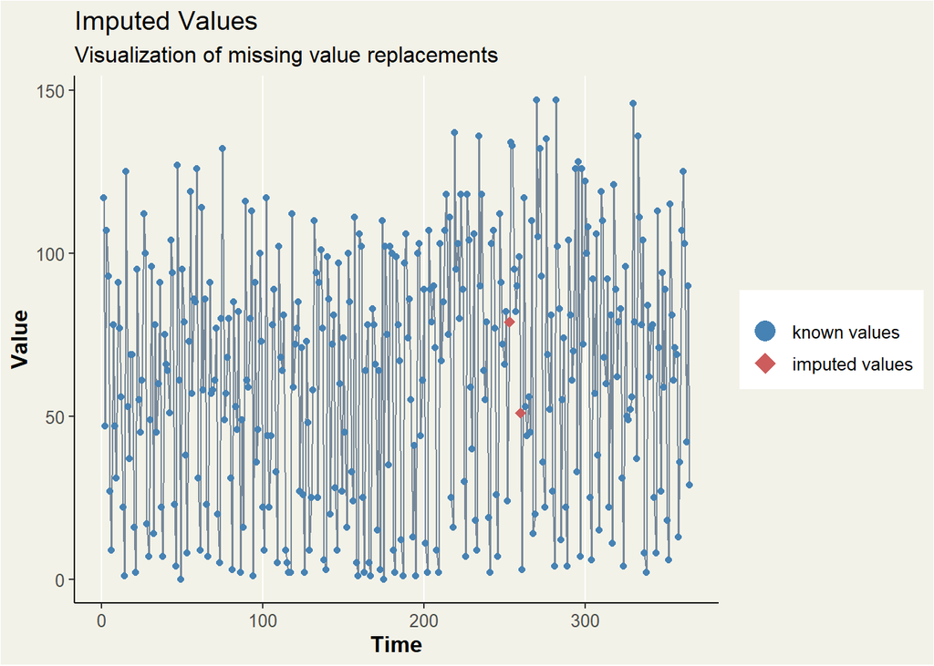

```r
#store imputation
imputation <- na_interpolation(atm$ATM2)
#plot imputation
ggplot_na_imputations(atm$ATM2, imputation) +
  my_plot_theme
```

```r
#incorporation imputation
atm$ATM2 <- imputation
```

## #2 Visualize the data

I plot each ATM as a boxplot below to get a better look at the distributions. ATM1 and ATM2 seem the most normally distributed, though there are quite a few outliers in ATM1. Further, ATM1 has a higher median value than ATM2.

ATM3 appears to be used quite rarely as there is essentially no box on this boxplot, just a few values that as a result appear as outliers. Finally, ATM4 has a very small range of values, however taking note of the scale this is an optics issue caused by that extreme outlier. We’ve stumbled on another data cleaning issue.

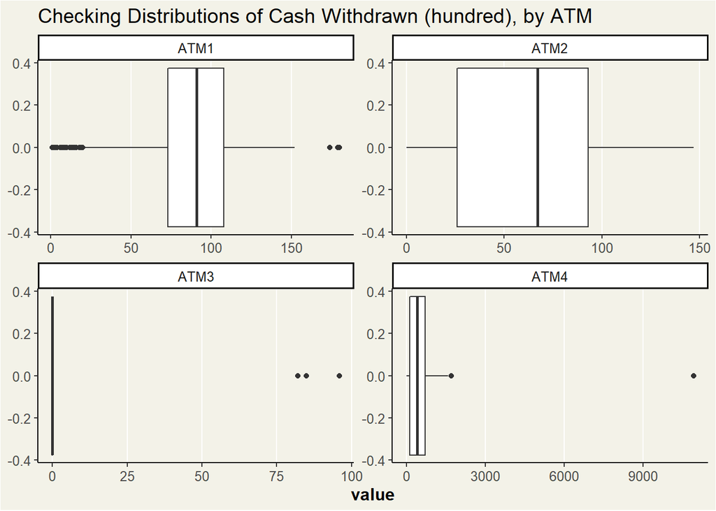

```r
atm %>%
  subset(select = -DATE) %>%
  gather() %>%
  ggplot(aes(value)) +
  geom_boxplot() +
  facet_wrap(~ key, scales = "free") +
  labs(title = "Checking Distributions of Cash Withdrawn (hundred), by ATM") +
  my_plot_theme
```

### Check for outliers

A nice function from the `statix` package allows it to see the number of cases that are outliers, and further how many at extreme outliers.

```r
atm <- data.frame(atm)
atm %>%
  identify_outliers(ATM1)
```

```
##          DATE ATM1 ATM2 ATM3 ATM4 is.outlier is.extreme
## 1  2010-01-21   12    1    0   49       TRUE      FALSE
## 2  2010-01-07   15    7    0  152       TRUE      FALSE
## 3  2009-10-01   14   14    0  108       TRUE      FALSE
## 4  2009-10-15    9    7    0    8       TRUE      FALSE
## 5  2009-10-22    9    4    0   61       TRUE      FALSE
## 6  2009-10-29    9    8    0    6       TRUE      FALSE
## 7  2009-10-08   13    9    0  124       TRUE      FALSE
## 8  2009-11-12   15    7    0   44       TRUE      FALSE
## 9  2009-11-19   10    5    0   32       TRUE      FALSE
## 10 2009-11-26   18    3    0   64       TRUE      FALSE
## 11 2009-11-30    6    2    0   47       TRUE      FALSE
## 12 2009-12-10   12    1    0   70       TRUE      FALSE
## 13 2009-12-17   14    9    0  129       TRUE      FALSE
## 14 2009-12-24   13    5    0   15       TRUE      FALSE
```

[output cut: 37 more lines]

ATM2 has no outliers at all.

```r
atm %>%
  identify_outliers(ATM2)
```

```
## [1] DATE       ATM1       ATM2       ATM3       ATM4       is.outlier is.extreme
## <0 rows> (or 0-length row.names)
```

ATM3 has the three outliers that were easy to identify on the boxplot above. Essentially all values in the ATM3 time series are zero, except for these three values. We see the dates below that these are in the last three days of the time span, which suggests this is a newly installed ATM. These aren’t actually outliers, but the start of the data for this particular ATM. Unfortunatley, with only 3 data points we won’t be able to do any meaningful forecasting, so these ATM will be disregarded moving forward.

```r
atm %>%
  identify_outliers(ATM3)
```

```
##         DATE ATM1 ATM2 ATM3 ATM4 is.outlier is.extreme
## 1 2010-04-28   96  107   96  348       TRUE       TRUE
## 2 2010-04-29   82   89   82   44       TRUE       TRUE
## 3 2010-04-30   85   90   85  482       TRUE       TRUE
```

```r
#remove ATM3 from dataframe
atm <- atm %>%
  select(-ATM3)
```

```r
atm %>%
  identify_outliers(ATM4)
```

```
##         DATE ATM1 ATM2  ATM4 is.outlier is.extreme
## 1 2010-02-09  123   45 10920       TRUE       TRUE
## 2 2009-09-22  180   89  1712       TRUE      FALSE
```

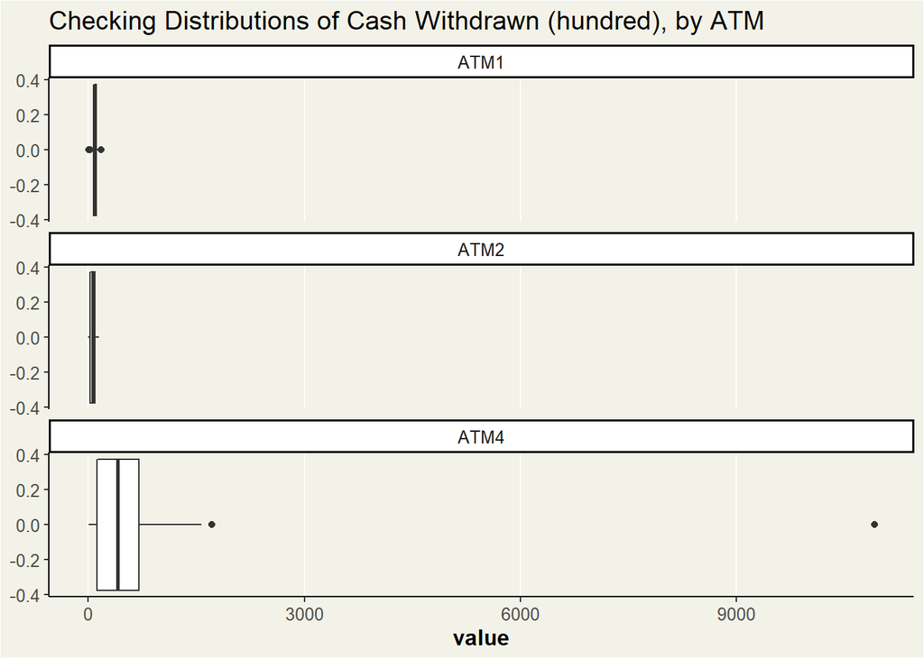

```r
#plot box-plots again
atm %>%
  subset(select = -DATE) %>%
  gather() %>%
  ggplot(aes(value)) +
  geom_boxplot() +
  facet_wrap(~ key, ncol = 1) +
  labs(title = "Checking Distributions of Cash Withdrawn (hundred), by ATM") +
  my_plot_theme
```

### Consider Transformations

Now I can proceed looking for trend, seasonality, and/or the need for Box-Cox transformation on each of the ATMs’ time series data.

ATM3 can be disregarded, as I’d recommend to my boss that this ATM is either broken or simply isn’t being used. By the look of the three other plots I don’t see any major changes in variance, that would greatly change the mean over time, so I conclude Box-Cox transformations are not necessary. There appears to be some seasonality on ATM1 and ATM2, possibly in ATM4 but it’s a bit less apparent. I would imagine this by days of the week, but I’ll need to check.

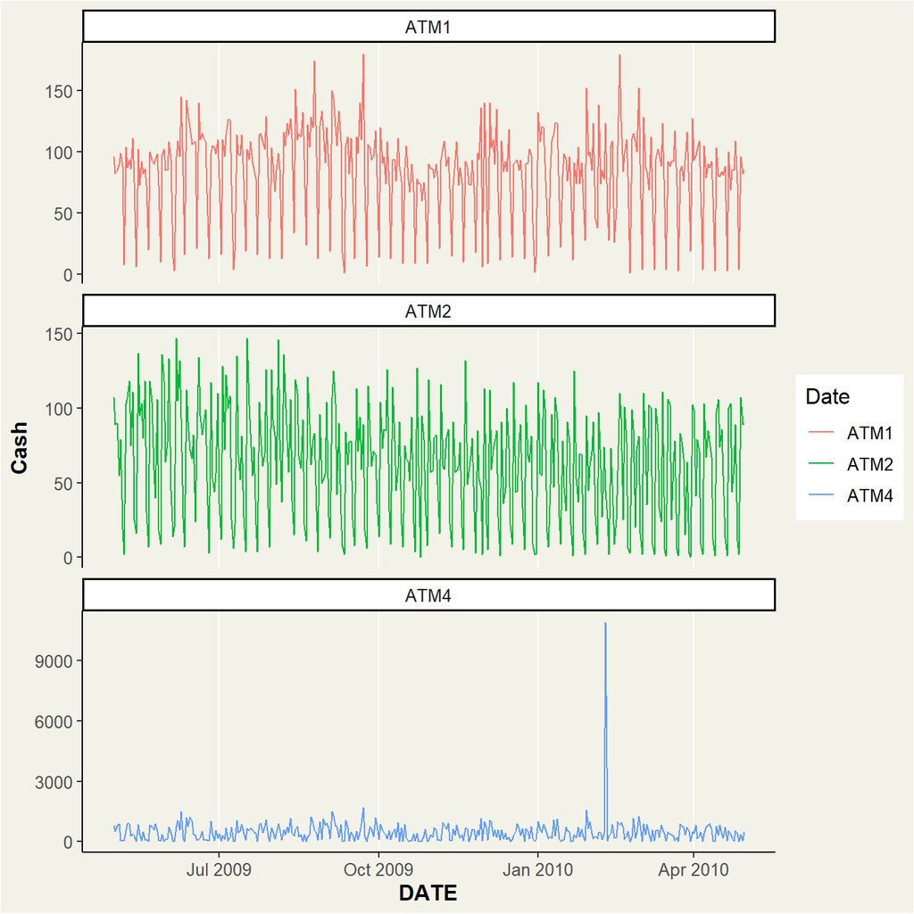

```r
#return to long data format in order to facet-wrap plot
atm %>%
  gather("Date", "Cash", "ATM1", "ATM2", "ATM4") %>%
  ggplot(aes(x = DATE, y = Cash, col = Date)) +
  geom_line() +
  facet_wrap(~Date, ncol = 1, scales = "free_y") +
  my_plot_theme
```

```r
atm1_ts <- atm %>%
  select(DATE, ATM1) %>%
  as_tsibble(index = DATE)
atm1_ts$ATM1 <- as.numeric(atm1_ts$ATM1)

atm2_ts <- atm %>%
  select(DATE, ATM2) %>%
  as_tsibble(index = DATE)

atm4_ts <- atm %>%
  select(DATE, ATM4) %>%
  as_tsibble(index = DATE)
```

ATM1

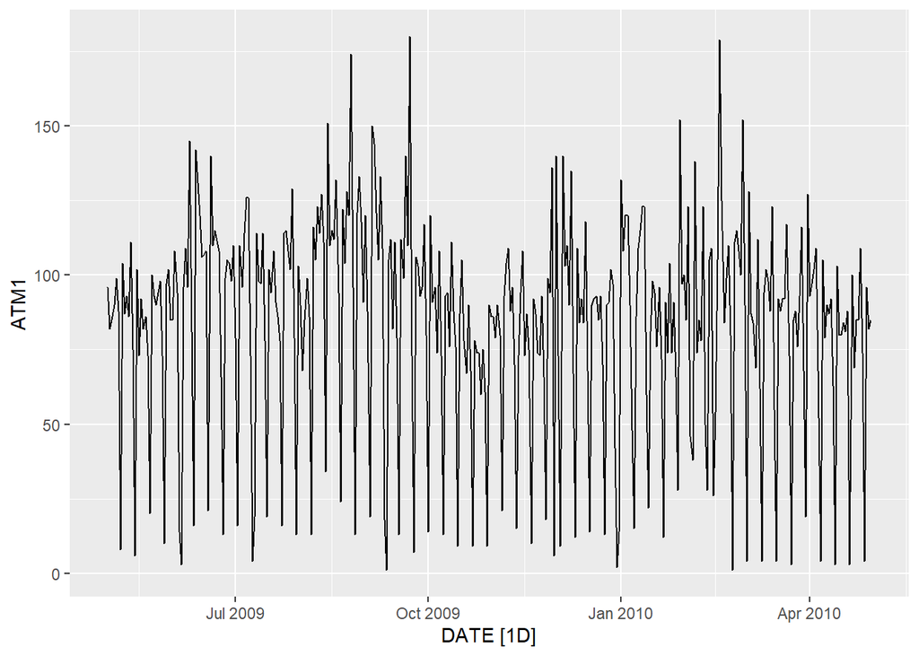

```r
atm1_ts %>%
  autoplot()
```

# Part B - Power Usage Forecast

Part B consists of a simple dataset of residential power usage for January 1998 until December 2013. Your assignment is to model these data and a monthly forecast for 2014. The data is given in a single file. The variable ‘KWH’ is power consumption in Kilowatt hours, the rest is straight forward. Add this to your existing files above.

## #1 Data preparation

Look at a summary of the data we see there are 3 variables, `CaseSequence` showing the order of the `YYYY-MMM` variable, and finally the `KWH` variable showing the power usage. `KWH` has one missing value we will want to impute before we proceed.

```r
power_raw <- read_csv("power_raw.csv")

skim(power_raw)
```

Data summary

| Name | power_raw |
| --- | --- |
| Number of rows | 192 |
| Number of columns | 3 |
| _______________________ |  |
| Column type frequency: |  |
| character | 1 |
| numeric | 2 |
| ________________________ |  |
| Group variables | None |

**Variable type: character**

| skim_variable | n_missing | complete_rate | min | max | empty | n_unique | whitespace |
| --- | --- | --- | --- | --- | --- | --- | --- |
| YYYY-MMM | 0 | 1 | 8 | 8 | 0 | 192 | 0 |

**Variable type: numeric**

| skim_variable | n_missing | complete_rate | mean | sd | p0 | p25 | p50 | p75 | p100 | hist |
| --- | --- | --- | --- | --- | --- | --- | --- | --- | --- | --- |
| CaseSequence | 0 | 1.00 | 828.5 | 55.57 | 733 | 780.75 | 828.5 | 876.25 | 924 | ▇▇▇▇▇ |
| KWH | 1 | 0.99 | 6502474.6 | 1447570.89 | 770523 | 5429912.00 | 6283324.0 | 7620523.50 | 10655730 | ▁▁▇▅▁ |

### Imputation

Below I use the `imputeTS` package to generate a value for the identified NA value, using the linear (default) method. The point seems reasonable and to take into account the seasonality we see in the data so I incorporate it.

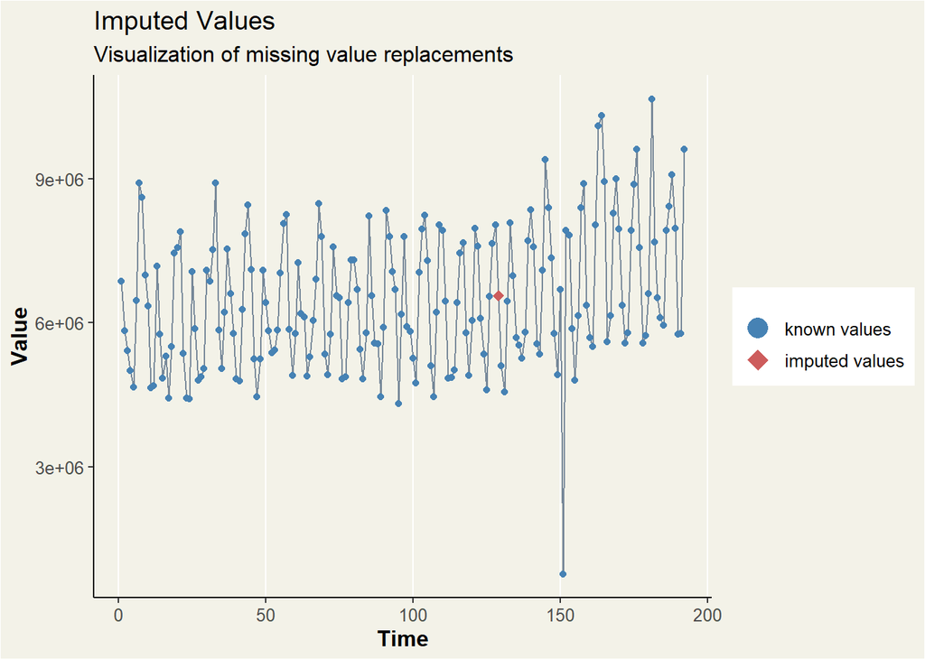

```r
#store imputation
imputation <- na_interpolation(power_raw$KWH)
#plot imputation
ggplot_na_imputations(power_raw$KWH, imputation) +
  my_plot_theme
```

```r
#incorporate imputation
power <- power_raw
power$KWH <- imputation
```

## #2 Visualize the data

I start by visualizing the data with a boxplot and see there is one low outlier we may want to check on.

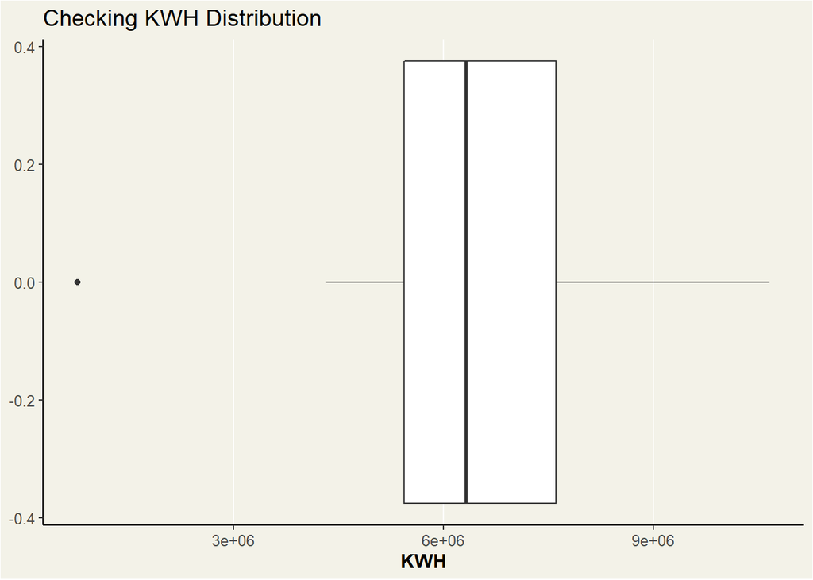

```r
power %>%
  subset(select = KWH) %>%
  ggplot(aes(KWH)) +
  geom_boxplot() +
  labs(title = "Checking KWH Distribution") +
  my_plot_theme
```

### Check for Outliers

The outlier shown above on the box plot appears to be from July 2010 and is not marked as an extreme value. In a real-world setting I would be curious to know from coworkers if there was a large outage for part of this month that decreased consumption, or possible a measurement error.

```r
power <- data.frame(power)
power %>%
  identify_outliers(KWH)
```

```
##   CaseSequence YYYY.MMM    KWH is.outlier is.extreme
## 1          883 2010-Jul 770523       TRUE      FALSE
```

```r
#power_ts <- power %>%
  #mutate(Month = yearmonth(`YYYY-MMM`)) %>%
#as_tsibble(index = Month)
```

```r
# power_ts %>%
#   ggplot(aes(x = Month, y = KWH)) +
#   geom_line() +
#   my_plot_theme
```